# Investigate_rnmf_poisson

## Goal

- Continue my investigation in https://zihao12.github.io/topics-simulation-experiments/Investigate_rnmf_least_square.html.
- Although randomized nmf works only for `Frobenius` loss now, it is still interesting to see how it performs on Poisson data.

## Method

- I simulate data (`p` = 5000, `n` = 1000) from a poisson model, then compute the average poisson loglikelihood, least square error of the fit.
- I use `Randomized NMF HALS`, `NMF HALS`, `skd.nmf`, all of which using `frobenius norm` as objective function; as a comparison, I also use `skd.nmf` that optimizes beta divergence (KL-like divergence).

## Summary of results

### Some Results

- It is difficult to fix time or objective loss by `tol` as they mean different things for those methods. But I pick results that are close to each other.

```
txt
method      time(s)   average least square
oracle                13.13443356826215
rnmf_hals   8.61      12.97007448295477
nmf_hals    268       12.97007448210494
skd.nmf      90       12.97007424537852
```

- `skdnmf` with `kl` as loss needs to spend significantly more time to get better poisson loglikelihood. In one case, `skdnmf kl` spends `360` seconds to get a `1e-03` advantage in poisson loglikelihood over `randomized nmf` which takes `0.75` seconds.

```
txt

method         time(s)   average poisson ll
oracle                   -2.5349285062516196
rnmf_hals      0.758     -2.5330424910987963
skd.nmf(kl)    360       -2.5319533605235485
```

- From the results above, I would say `randomized NMF` mainly has an advantage in terms of speed, while its loss is not significantly worse than the other methods.

### Relationship between poisson loglikelihood and least square (see plot in the end)

- there is a linear relationship between log of least square and log of tolerance;
- log of poisson loglikelihood also increases linearly as log of tolerance increases, until `tol = 1e-04`, where the maximum poisson loglikelihood is reached; then likelihood decreases little bit, around `1e-07`.
- this might suggest we can initialize algorithm that optimizes beta divergence with `forbenius` loss first, then switch back to beta divergence.

```python
import numpy as np
import os
import sys
import time
sys.path.insert(0,'../code/')
from utility import compute_loglik
import ristretto
from ristretto.nmf import compute_nmf
from ristretto.nmf import compute_rnmf
from scipy.stats import poisson
from sklearn.decomposition import NMF
```

```python
def compute_least_sqr_loss(X,Lam):
    p, n = X.shape
    return (np.square((X - Lam))).sum()/(n*p)
```

```python
def simulate_pois(n, p, rank, seed=0):
    np.random.seed(seed)
    W = np.random.normal(size=(rank, n))
    W = np.exp(W)
    A = np.random.normal(size=(p, rank))
    A = np.exp(A)
    Lam = A.dot(W)
    X = np.random.poisson(lam=Lam)
    ll = compute_loglik(X,A,W)
    return X, Lam, ll['poisson_ll']
```

```python
n = 1000
p = 5000
r = 5
np.random.seed(123)
X, Lam,p_ll = simulate_pois(n,p,r)
ls_ll = compute_least_sqr_loss(X,Lam)
print("mean poisson ll     : " + str(p_ll))
print("mean least square ll: " + str(ls_ll))
```

```
mean poisson ll     : -2.5349285062516196
mean least square ll: 13.134433568262152
```

```python
print("X shape: p " + str(X.shape[0]) + " n ", str(X.shape[1]))
```

```
X shape: p 5000 n  1000
```

## NMF with HALS

### init = 'nndsvd'

```python
start = time.time()
A,W = compute_nmf(X,rank=r,init = 'nndsvd',tol=1e-4, maxiter=10000)
runtime = time.time() - start
print("runtime: " + str(runtime))
ll = compute_loglik(X,A,W)
ls_ll = compute_least_sqr_loss(X,A.dot(W))
print("mean poisson ll: " + str(ll["poisson_ll"]))
print("mean least square ll: " + str(ls_ll))
```

```
runtime: 12.47459101676941
mean poisson ll: -2.5330425144350746
mean least square ll: 12.970121467393719
```

```python
start = time.time()
A,W = compute_nmf(X,rank=r,init = 'nndsvd',tol=1e-5, maxiter=10000)
runtime = time.time() - start
print("runtime: " + str(runtime))
ll = compute_loglik(X,A,W)
ls_ll = compute_least_sqr_loss(X,A.dot(W))
print("mean poisson ll: " + str(ll["poisson_ll"]))
print("mean least square ll: " + str(ls_ll))
```

```
runtime: 71.45459294319153
mean poisson ll: -2.533042901540544
mean least square ll: 12.970077403058497
```

```python
start = time.time()
A,W = compute_nmf(X,rank=r,init = 'nndsvd', tol=1e-10, maxiter=10000)
runtime = time.time() - start
print("runtime: " + str(runtime))
ll = compute_loglik(X,A,W)
ls_ll = compute_least_sqr_loss(X,A.dot(W))
print("mean poisson ll: " + str(ll["poisson_ll"]))
print("mean least square ll: " + str(ls_ll))
```

```
runtime: 268.52411007881165
mean poisson ll: -2.533042928853668
mean least square ll: 12.97007448210494
```

### Comment:

It takes very long to improve loss (least square, poisson loglikelihood decreases a little bit) at later stage.

### init = 'nndsvda'

```python
start = time.time()
A,W = compute_nmf(X,rank=r,init = 'nndsvda')
runtime = time.time() - start
print("runtime: " + str(runtime))
ll = compute_loglik(X,A,W)
ls_ll = compute_least_sqr_loss(X,A.dot(W))
print("mean poisson ll: " + str(ll["poisson_ll"]))
print("mean least square ll: " + str(ls_ll))
```

```
runtime: 4.950164079666138
mean poisson ll: -2.533045441204308
mean least square ll: 12.970269038806004
```

## Randomized NMF with HALS

### init = 'nndsvd'

```python
start = time.time()
A,W = compute_rnmf(X,rank=r, init = 'nndsvd',random_state = 0,tol=1e-4, maxiter=10000)
runtime = time.time() - start
print("runtime: " + str(runtime))
ll = compute_loglik(X,A,W)
ls_ll = compute_least_sqr_loss(X,A.dot(W))
print("mean poisson ll: " + str(ll["poisson_ll"]))
print("mean least square ll: " + str(ls_ll))
```

```
runtime: 0.7580208778381348
mean poisson ll: -2.5330424910987963
mean least square ll: 12.970121436446632
```

```python
start = time.time()
A,W = compute_rnmf(X,rank=r, init = 'nndsvd',random_state = 0,tol=1e-5, maxiter=10000)
runtime = time.time() - start
print("runtime: " + str(runtime))
ll = compute_loglik(X,A,W)
ls_ll = compute_least_sqr_loss(X,A.dot(W))
print("mean poisson ll: " + str(ll["poisson_ll"]))
print("mean least square ll: " + str(ls_ll))
```

```
runtime: 2.451042890548706
mean poisson ll: -2.5330428996475707
mean least square ll: 12.970077400281738
```

```python
start = time.time()
A,W = compute_rnmf(X,rank=r, init = 'nndsvd',random_state = 0, tol=1e-10, maxiter=10000)
runtime = time.time() - start
print("runtime: " + str(runtime))
ll = compute_loglik(X,A,W)
ls_ll = compute_least_sqr_loss(X,A.dot(W))
print("mean poisson ll: " + str(ll["poisson_ll"]))
print("mean least square ll: " + str(ls_ll))
```

```
runtime: 8.610498905181885
mean poisson ll: -2.533042929707264
mean least square ll: 12.970074482954777
```

## Comment:

### init = 'nndsvda'

```python
start = time.time()
A,W = compute_rnmf(X,rank=r, init = 'nndsvda',random_state = 0)
runtime = time.time() - start
print("runtime: " + str(runtime))
ll = compute_loglik(X,A,W)
ls_ll = compute_least_sqr_loss(X,A.dot(W))
print("mean poisson ll: " + str(ll["poisson_ll"]))
print("mean least square ll: " + str(ls_ll))
```

```
runtime: 0.5367460250854492
mean poisson ll: -2.533045419417474
mean least square ll: 12.97027273074913
```

## skdNMF `cd` solver

### init="nndsvd"

```python
start = time.time()
#print("fit")
model = NMF(n_components=r, init="nndsvd", tol = 1e-04, beta_loss='frobenius',solver = "cd",
                random_state=0, max_iter = 10000, verbose = False)
model.fit(X.T)
#print("transform")
L = model.transform(X.T)
runtime = runtime = time.time() - start
print("runtime: " + str(runtime))
F = model.components_
A = F.T
W = L.T
ll = compute_loglik(X,A,W)
ls_ll = compute_least_sqr_loss(X,A.dot(W))
print("mean poisson ll: " + str(ll["poisson_ll"]))
print("mean least square ll: " + str(ls_ll))
```

```
runtime: 4.01442289352417
mean poisson ll: -2.5330425361803606
mean least square ll: 12.970121605388746
```

### init = "nndsvda"

```python
start = time.time()
#print("fit")
model = NMF(n_components=r, init="nndsvda", tol = 1e-05, beta_loss='frobenius',solver = "cd",
                random_state=0, max_iter = 10000, verbose = False)
model.fit(X.T)
#print("transform")
L = model.transform(X.T)
runtime = runtime = time.time() - start
print("runtime: " + str(runtime))
F = model.components_
A = F.T
W = L.T
ll = compute_loglik(X,A,W)
ls_ll = compute_least_sqr_loss(X,A.dot(W))
print("mean poisson ll: " + str(ll["poisson_ll"]))
print("mean least square ll: " + str(ls_ll))
```

```
runtime: 1.892904281616211
mean poisson ll: -2.5330453981473537
mean least square ll: 12.97026796856582
```

```python
start = time.time()
#print("fit")
model = NMF(n_components=r, init="nndsvda", tol = 1e-10, beta_loss='frobenius',solver = "cd",
                random_state=0, max_iter = 10000, verbose = False)
model.fit(X.T)
#print("transform")
L = model.transform(X.T)
runtime = runtime = time.time() - start
print("runtime: " + str(runtime))
F = model.components_
A = F.T
W = L.T
ll = compute_loglik(X,A,W)
ls_ll = compute_least_sqr_loss(X,A.dot(W))
print("mean poisson ll: " + str(ll["poisson_ll"]))
print("mean least square ll: " + str(ls_ll))
```

```
runtime: 90.68843197822571
mean poisson ll: -2.5330428298133887
mean least square ll: 12.970074245378528
```

### beta_loss='kullback-leibler', init = 'nndsvda'

```python
start = time.time()
#print("fit")
model = NMF(n_components=r, init="nndsvda", tol = 1e-08, beta_loss='kullback-leibler',solver = "mu",
                random_state=0, max_iter = 10000, verbose = False)
model.fit(X.T)
#print("transform")
L = model.transform(X.T)
runtime = runtime = time.time() - start
print("runtime: " + str(runtime))
F = model.components_
A = F.T
W = L.T
ll = compute_loglik(X,A,W)
ls_ll = compute_least_sqr_loss(X,A.dot(W))
print("mean poisson ll: " + str(ll["poisson_ll"]))
print("mean least square ll: " + str(ls_ll))
```

```
runtime: 327.79424118995667
mean poisson ll: -2.532089171868993
mean least square ll: 13.027651495411714
```

### beta_loss='kullback-leibler', init = 'random'

```python
start = time.time()
#print("fit")
model = NMF(n_components=r, init="random", tol = 1e-08, beta_loss='kullback-leibler',solver = "mu",
                random_state=0, max_iter = 10000, verbose = False)
model.fit(X.T)
#print("transform")
L = model.transform(X.T)
runtime = runtime = time.time() - start
print("runtime: " + str(runtime))
F = model.components_
A = F.T
W = L.T
ll = compute_loglik(X,A,W)
ls_ll = compute_least_sqr_loss(X,A.dot(W))
print("mean poisson ll: " + str(ll["poisson_ll"]))
print("mean least square ll: " + str(ls_ll))
```

```
runtime: 360.9263050556183
mean poisson ll: -2.5319533605235485
mean least square ll: 13.020975179626744
```

### Comment:

skdnmf seems to have very slow convergence rate in the later stage

## Poisson ll and least square

It is possible that at the early stage of minimizing least square, poisson loglikelihood also drops. If that is true, maybe we can use `frobenius` loss at the earlsy stage and swith back at a later stage.

```python
p_lls = []
ls_lls = []
mytime = []
tol = [10**(-e) for e in range(10)]
for t in tol:
    start = time.time()
    A,W = compute_rnmf(X,rank=r, init = 'nndsvd',random_state = 0, tol = t, maxiter = 100000)
    runtime = time.time() - start
    p_ll = compute_loglik(X,A,W)
    ls_ll = compute_least_sqr_loss(X,A.dot(W))
    mytime.append(runtime)
    p_lls.append(p_ll["poisson_ll"])
    ls_lls.append(ls_ll)
```

```python
import matplotlib.pyplot as plt
```

```
Text(0.5,1,'log of tolerance vs time')
```

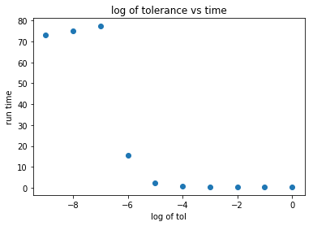

```python
plt.scatter(np.log10(tol), mytime)
plt.xlabel("log of tol")
plt.ylabel("run time")
plt.title("log of tolerance vs time")
```

```
Text(0.5,1,'tol vs least square')
```

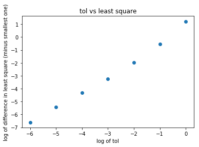

```python
ls_lls_scaled = [ls - min(ls_lls) for ls in ls_lls]
plt.scatter(np.log10(tol[:-1]), np.log10(ls_lls_scaled[:-1]))
plt.xlabel("log of tol")
plt.ylabel("log of difference in least square (minus smallest one)")
plt.title("tol vs least square")
```

```
Text(0.5,1,'tol vs poisson loglikelihood')
```

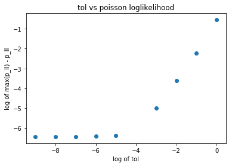

```python
p_lls_scaled = [max(p_lls) -ls for ls in p_lls]
plt.scatter(np.log10(tol), np.log10(p_lls_scaled))
plt.xlabel("log of tol")
plt.ylabel("log of max(p_ll) - p_ll")
plt.title("tol vs poisson loglikelihood")
```

### Comment:

- there is a linear relationship between log of least square and log of tolerance;
- log of poisson loglikelihood also increases linearly as log of tolerance increases, until `tol = 1e-04`, where the maximum poisson loglikelihood is reached; then likelihood decreases little bit, around `1e-07`.
- this might suggest we can initialize algorithm that optimizes beta divergence with `forbenius` loss first, then switch back to beta divergence.